# Investments

Week 3 – CAPM test and out-of-sample quantile performance in R  
Utz Weitzel – VU Finance

> This is bonus material in the course, which may be useful for your thesis project or other data-related work. The code below introduces in-sample estimations with out-of-sample predictions, which are widely used in practice and research. So, although this material is not relevant for the exam, it may still be worthwhile to study the code.

# Prepare session

In RStudio, open a project, or make a new one.

**Load the Tidyverse package**

```r
if(!require(tidyverse)) install.packages("tidyverse")
library(tidyverse)
options(dplyr.summarise.inform = FALSE)
```

# Testing beta

## Import data

For this section, we import dataset `df302` with *monthly* data from 2018 to 2023 for all stocks (listed in `ticker` by `date`, `year`, and `month`) that are included in the S&P500 Index (as of March 2024, based on [this list](https://stockanalysis.com/list/sp-500-stocks/)) with *non-missing return data* for the last six years.

Main variables are: `re` = total ETF portfolio returns; `SP500` = total market index returns; `rf` = risk-free returns to 4-week T-bills; `SML` = excess returns on Fama-French (FF) SMB portfolios; `HML` = excess returns on FF HML portfolios.

```r
df302 = read_csv("df302.csv", show_col_types=FALSE)
```

## Excess returns

For most analyses we use *excess* returns.

```r
df302 = df302 |>
  mutate(rx = re-rf) |> # excess stock return
  mutate(rm = SP500-rf) # excess market return
```

## 1st-pass regressions

Let’s get each stock’s estimates of a CAPM model and some other information, which we need later on.

```r
df302q = df302 |>
  group_by(ticker) |>
  summarize(model = list(lm(rx ~ rm, data = pick(rx, rm))),
            rm_av = mean(rm, na.rm=T),
            rx_av = mean(rx, na.rm=T)) |>
  mutate(beta  = map_dbl(model, ~ coef(.)["rm"])) |>
  mutate(sd_e  = map_dbl(model, ~ sd(resid(.)))) |>
  select(-model)
```

**Note**

We use the term “first-pass regression” to refer to the fact that the regression results (e.g., a stock’s beta) are used for further analysis in second-pass regressions (as explained in Chapter 13.1).

## 2nd-pass regressions

In the second-pass regression, we fit a linear model of each stock’s `beta` and `sd_e` on the average excess stock return `rx_av` (see Chapter 13.1). According to CAPM, we expect to see

- H1: an intercept that is statistically equal to zero
- H2: a coefficient of the stocks’ `beta` is statistically equal to the excess market return `rm_av`
- H3: a coefficient of the stocks’ `sd_e` that is statistically equal to zero

```r
lm_btest = lm(rx_av ~ beta + sd_e, data = df302q)

summary(lm_btest)
```

```
Call:
lm(formula = rx_av ~ beta + sd_e, data = df302q)

Residuals:
      Min        1Q    Median        3Q       Max
-0.027173 -0.004756 -0.000574  0.004172  0.053416

Coefficients:
             Estimate Std. Error t value Pr(>|t|)
(Intercept) 2.198e-05  1.183e-03   0.019    0.985
beta        4.462e-03  1.134e-03   3.935 9.65e-05 ***
sd_e        9.249e-02  1.779e-02   5.199 3.05e-07 ***
---
Signif. codes:  0 '***' 0.001 '**' 0.01 '*' 0.05 '.' 0.1 ' ' 1

Residual standard error: 0.008097 on 450 degrees of freedom
Multiple R-squared:  0.1827,    Adjusted R-squared:  0.1791
F-statistic:  50.3 on 2 and 450 DF,  p-value: < 2.2e-16
```

We do not reject H1, but H3 is clearly rejected with a positive coefficient estimate and a t-value>5. Rejecting H3 means that, in this sample, idiosyncratic risk matters and is priced with higher expected returns (against the prediction of the CAPM).

## Test for H2

H2 predicts that the estimated coefficient of `beta` is statistically equal to the average excess market return `rm_av`. Lets compute the confidence interval for the coefficient of beta and see whether it includes `rm_av`.

```r
rm_av_value = unique(df302q$rm_av)
cat("Expected excess return of market: ", rm_av_value, "\n")
```

```
Expected excess return of market:  0.007951264
```

```r
coef_beta = coef(lm_btest)["beta"]
cat("Estimated coefficient of beta:    ", coef_beta, "\n\n")
```

```
Estimated coefficient of beta:     0.004462049
```

```r
# save CI's for all estimated model coefficients, incl intercept:
CI95 = confint(lm_btest, level = 0.95)
CI99 = confint(lm_btest, level = 0.99)

# return CI's for beta only:
cat("95% CI of coefficient:", CI95["beta",], "\n")
```

```
95% CI of coefficient: 0.002233347 0.006690751
```

```r
cat("99% CI of coefficient:", CI99["beta",], "\n")
```

```
99% CI of coefficient: 0.001528476 0.007395622
```

The average return of the market is just above the higher bound of the 95% and 99% confidence intervals of the coefficient estimate of beta. This means that we can reject H2.

In total, based on this sample, we reject two out of three hypotheses of the CAPM.

# Out-of-Sample Performance of Quantile Portfolios

What if we estimated quantiles on only the first half of the data? Let us call this the **in-sample period**, which consists of the first three years of data: 2018, 2019 and 2020.

Then we construct quantile portfolios based on the 2018-2020 estimates of alpha, beta, std, and sde. Now we will check the performance of these quantile portfolio **out-of-sample**, hence in 2021-2023.

We ask ourselves: *Do high alpha/beta/std/sde quantile portfolios based on the period 2018-2020 earn a higher average return in 2021-2023 (out-of-sample) as well?*

## Step 1: Define in-sample period

Define the in-sample period to be the first three years of data: 2018 - 2020.

```r
# Filter out the years 2018, 2019, 2020
df303_in = df302 |>
  filter(year == 2018 | year == 2019 | year == 2020)
```

## Step 2: Define out-of-sample period

Define the out-of-sample period to be the last three years of data: 2021 - 2023.

```r
# Filter out the years 2021, 2022, 2023
df303_out = df302 |>
  filter(year == 2021 | year == 2022 | year == 2023)
```

## Step 3: Estimate alpha, beta, std, sde (in-sample)

Estimate alpha, beta, std, sde in-sample (2018-2020) following the procedure of Lecture 2.

```r
# Obtain the avg market and excess returns, std, beta, and sde during 2018-2020
df303q_in = df303_in |>
  group_by(ticker) |> # do this for each stock (ticker)
  summarize(model = list(lm(rx ~ rm, data = pick(rx, rm))), # regression model
            rm_av = mean(rm, na.rm=T), # avg. market return
            rx_av = mean(rx, na.rm=T), # avg. stock return
            rx_sd = sd(rx, na.rm=T)) |>     # stock standard deviation
  mutate(alpha = map_dbl(model, ~ coef(.)[1])) |>     # alpha
  mutate(beta  = map_dbl(model, ~ coef(.)["rm"])) |>  # beta
  mutate(sd_e  = map_dbl(model, ~ sd(resid(.)))) |>   # sde
  select(-model)

View(df303q_in)
```

## Step 4: Construct in-sample quantiles

We construct quantiles based on the in-sample estimates (2018-2020)

```r
# Construct decile portfolio based on 2018-2023 betas, std, sde
df303q_in = df303q_in |>
  mutate(q_alpha = ntile(alpha, 10)) |> # high quantile = high value
  mutate(q_beta = ntile(beta, 10)) |>
  mutate(q_sdx  = ntile(rx_sd, 10)) |>
  mutate(q_sde  = ntile(sd_e, 10)) |>
  select(ticker, q_alpha, q_beta, q_sdx, q_sde) # drop unnecessary columns

View(df303q_in)
```

**Merge data**

Merge the out-of-sample data (2021-2023) with the estimated in-sample quantiles (2018-2020)

```r
# Merge by ticker
df303q = merge(df303_out, df303q_in, by = c("ticker"))

View(df303q)
```

## Step 5: Calculate out-of-sample HPRs

Obtain holding period returns for each stock during the out-of-sample period (2021-2023)

```r
# For each stock, estimate holding period returns out-of-sample (2021-2023)
df303q = df303q |>
  group_by(ticker) |>
  summarize(SP500_hpr = prod(1+SP500, na.rm=T)-1, # market HPR
            re_hpr = prod(1+re, na.rm=T)-1,       # stock HPR
            rf_hpr = prod(1+rf, na.rm=T)-1,       # rf HPR
            rm_av = mean(rm, na.rm=T), # estimate average excess market returns
            rx_av = mean(rx, na.rm=T), # estimate average excess stock returns
            rx_sd = sd(rx, na.rm=T), # estimate standard deviations
            q_alpha = first(q_alpha), # keep the alpha quantiles
            q_beta = first(q_beta), # keep the beta quantiles
            q_sdx = first(q_sdx), # keep the sdx quantiles
            q_sde = first(q_sde)) # keep the sde quantiles

View(df303q)
```

## Step 6: Analyze results

We can now analyze the out-of-sample performance of the quantile portfolios that were constructed using in-sample data. Let us look at four different quantile portfolios.

**6.1 Q-Alpha in-sample vs. avg returns out-of-sample**

*Is the average excess out-of-sample return higher for high-alpha stocks (estimated in-sample)?*

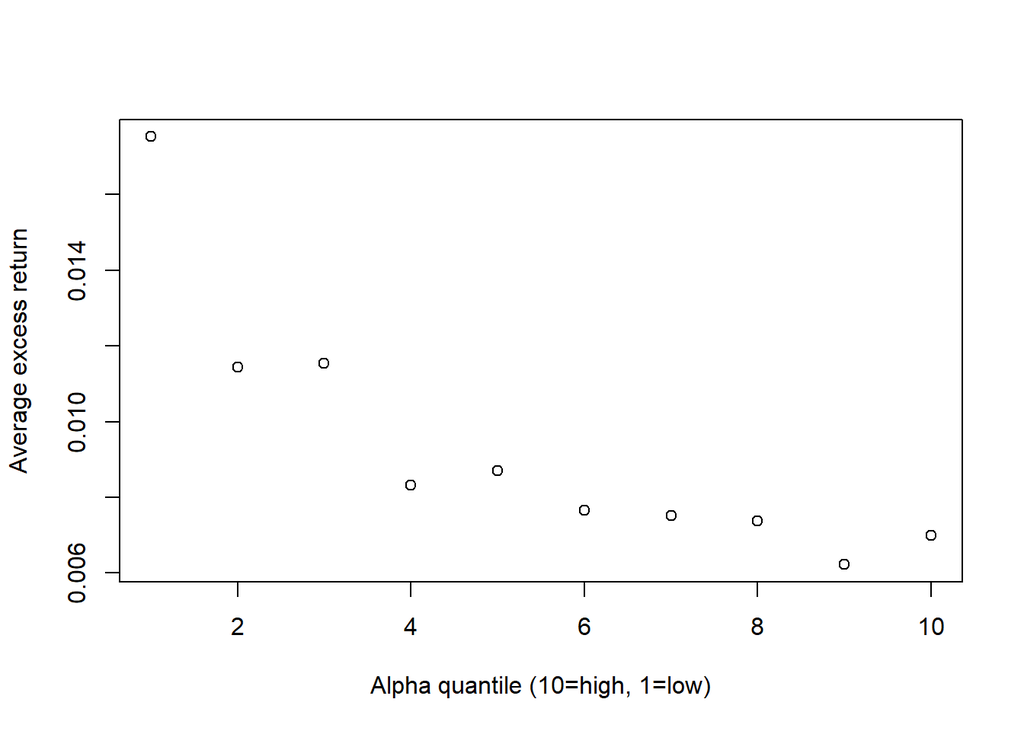

```r
df303q_alpha = df303q |>
  group_by(q_alpha) |>   # for all stocks in each of the ten alpha quantiles..
  summarize(mean_rx = mean(rx_av))  # .. we investigate the average excess return

plot(df303q_alpha$mean_rx, xlab = "Alpha quantile (10=high, 1=low)", ylab = "Average excess return")
```

**6.2 Q-Beta in-sample vs. avg returns out-of-sample**

*Is the average excess out-of-sample return higher for high-beta stocks (estimated in-sample)?*

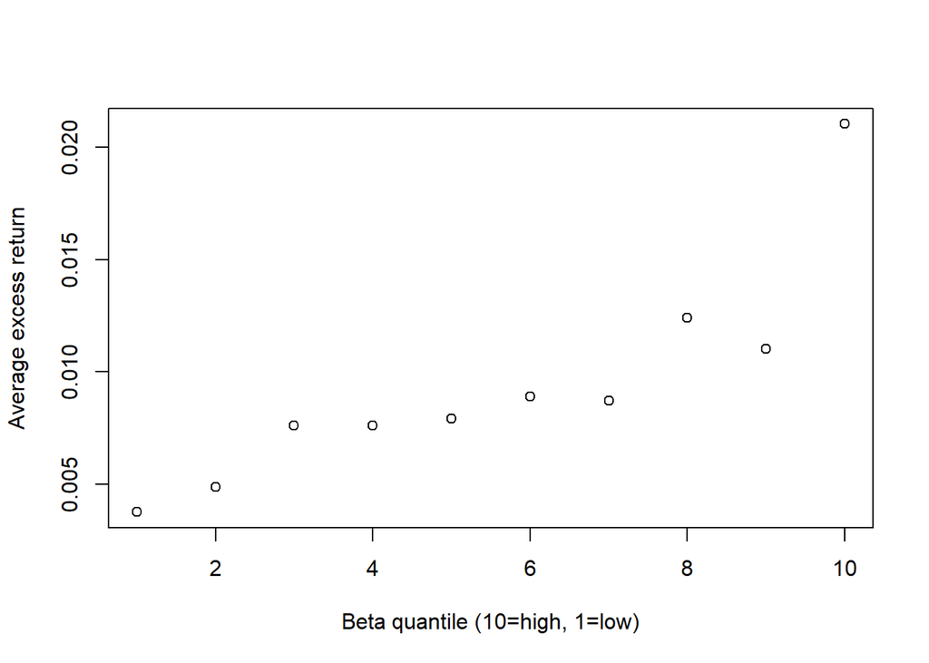

```r
df303q_beta = df303q |>
  group_by(q_beta) |> # for all stocks in each of the ten beta quantiles..
  summarize(mean_rx = mean(rx_av)) # .. we investigate the average excess return

plot(df303q_beta$mean_rx, xlab = "Beta quantile (10=high, 1=low)", ylab = "Average excess return")
```

**6.3 Q-Std in-sample vs. avg returns out-of-sample**

*Is the average excess out-of-sample return higher for high-std stocks (estimated in-sample)?*

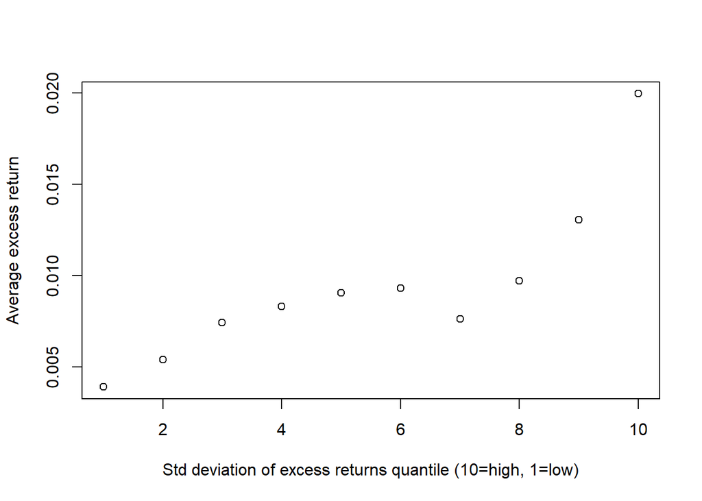

```r
df303q_std = df303q |>
  group_by(q_sdx) |> # for all stocks in each of the ten sdx quantiles..
  summarize(mean_rx = mean(rx_av)) # .. we investigate the average excess return

plot(df303q_std$mean_rx, xlab = "Std deviation of excess returns quantile (10=high, 1=low)", ylab = "Average excess return")
```

**6.4 Q-Sde in-sample vs. avg returns out-of-sample**

*Is the average excess out-of-sample return higher for high-sde stocks (estimated in-sample)?*

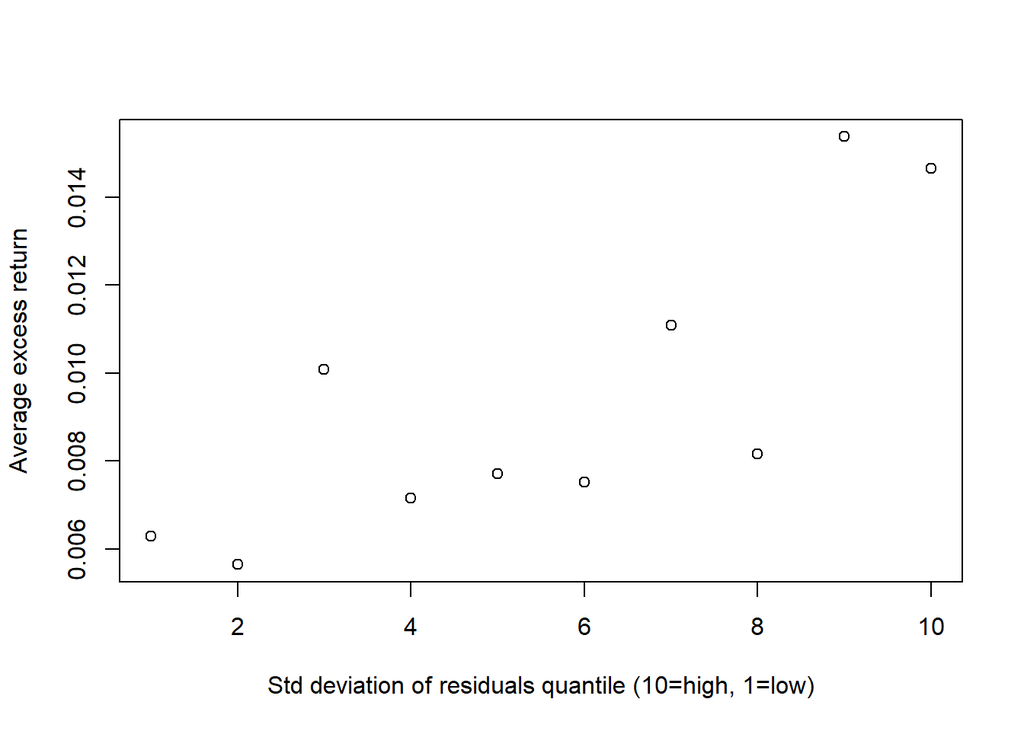

```r
df303q_sde = df303q |>
  group_by(q_sde) |> # for all stocks in each of the ten sde quantiles..
  summarize(mean_rx = mean(rx_av)) # .. we investigate the average excess return

plot(df303q_sde$mean_rx, xlab = "Std deviation of residuals quantile (10=high, 1=low)", ylab = "Average excess return")
```

**Conclusion:** High beta and high std quantile portfolios based on the in-sample data (2018-2020) also earn a higher average return out-of-sample! The effect for the sde portfolios has become weaker out-of-sample, although we can still roughly say that high sde portfolios in-sample earn a higher average return out-of-sample. For high alpha quantile portfolios, the effect is now opposite out-of-sample: portfolios that earned a high alpha in the in-sample period perform poorly out-of-sample.